# HW05

Rahul Sirasao (sirasao2)

October 17, 2016

# Directions

Students are encouraged to work together on homework. However, sharing, copying or providing any part of a homework solution or code is an infraction of the University’s rules on Academic Integrity. Any violation will be punished as severely as possible.

Final submissions must be uploaded to our Compass 2g site on the Homework page. No email, hardcopy, or late submissions will be accepted.

- Your assignment must be submitted through the [submission link](https://compass2g.illinois.edu/webapps/assignment/uploadAssignment?content_id=_2304825_1&course_id=_28042_1&assign_group_id=&mode=cpview) on **Compass 2g.** You are required to attach one `.zip` file, named `hw05_yourNetID.zip`, which contains:
  - Your RMarkdown file which should be saved as `hw05_yourNetID.Rmd`. For example `hw05_dunger.Rmd`.
  - The result of knitting your RMarkdown file as `hw05_yourNetID.html`. For example `hw05_dunger.html`.
- Your resulting `.html` file will be considered a “report” which is the material that will determine the majority of your grade. Be sure to visibly include all `R` code and output that is relevant to answering the exercises. (You do not need to include irrelevant code you tried that resulted in error or did not answer the question correctly.)
- You are granted an unlimited number of submissions, but only the last submission *before* the deadline will be viewed and graded.
- If you use this `.Rmd` file as a template, be sure to remove the directions section. Consider removing `eval = FALSE` from any code chunks provided in the template, if you would like to run that code as part of your assignment.
- Your `.Rmd` file should be written such that, if it is placed in a folder with any data your are asked to import, it will knit properly without modification.
- Unless otherwise stated, you may use `R` for each of the exercises.
- Be sure to read each exercise carefully!
- Include your Name and NetID in the final document, not only in your filenames.

# Assignment

## Exercise 1 (Iris data)

For this exercise we will use the `iris` dataset. This is a default dataset in `R`, so there is no need to load it. You should use `?iris` to learn about the background of this dataset.

**(a)** Perform the analysis of variance for the mean `Petal.Length` of the three `Species`. You’ll need to use the `anova` and `lm` function with petal length as the response and species as the predictor.

Report the following:

- The null and alternative hypotheses.
- The ANOVA table. (You may use `anova()` and omit the row for Total.)
- The value of the test statistic.
- The p-value of the test.
- A statistical decision at $\alpha = 0.05$.
- A conclusion in the context of the problem.

When reporting these, you should explicitly state them in your document, not assume that a reader will find and interpret them from a large block of `R` output.

```r
iris_full = lm(formula = iris$Petal.Length~iris$Species, data = iris)
summary(iris_full)
```

```
##
## Call:
## lm(formula = iris$Petal.Length ~ iris$Species, data = iris)
##
## Residuals:
##    Min     1Q Median     3Q    Max
## -1.260 -0.258  0.038  0.240  1.348
##
## Coefficients:
##                        Estimate Std. Error t value Pr(>|t|)
## (Intercept)             1.46200    0.06086   24.02   <2e-16 ***
## iris$Speciesversicolor  2.79800    0.08607   32.51   <2e-16 ***
## iris$Speciesvirginica   4.09000    0.08607   47.52   <2e-16 ***
## ---
## Signif. codes:  0 '***' 0.001 '**' 0.01 '*' 0.05 '.' 0.1 ' ' 1
##
## Residual standard error: 0.4303 on 147 degrees of freedom
## Multiple R-squared:  0.9414, Adjusted R-squared:  0.9406
## F-statistic:  1180 on 2 and 147 DF,  p-value: < 2.2e-16
```

```r
anova(iris_full)
```

```
## Analysis of Variance Table
##
## Response: iris$Petal.Length
##               Df Sum Sq Mean Sq F value    Pr(>F)
## iris$Species   2 437.10 218.551  1180.2 < 2.2e-16 ***
## Residuals    147  27.22   0.185
## ---
## Signif. codes:  0 '***' 0.001 '**' 0.01 '*' 0.05 '.' 0.1 ' ' 1
```

```r
#Null: There is no significant linear relationship betwen the mean petal.length and species.
#beta_1 = 0
#Alternative: There is a significant linear relationship between mean petal.length and species.
#beta_1 != 0

#The value of the test statistic is 1180.2

#p-value is < 2.2e-16 and is very small (and smaller than alpha) therefore we reject the null hypothesis at any reasonable  alpha  level, in this case at alpha=0.05. If the p value is less than alpha we reject the null hypothesis.

#The regression is significant. The variable species has a useful linear relationship with Petal.length
```

## Exercise 2 (GPA data)

For this exercise, we will use the data stored in `sportgpa.dat`. It contains the mean grade point averages of students participating in sports programs at 30 universities nationwide.

- `School` - Observation number representing the university
- `Baseball`, `Football`, `Soccer`, `Softball`, `Volleyball` - Average GPA of student-athletes playing this sport

**(a)** Find the sample mean and standard deviation for each of the five sports.

```r
sportgpa <- as.vector(read.table("../sirasao2_hw05/sportgpa(1).dat", header = TRUE))
#baseball
mean(sportgpa$Baseball)
```

```
## [1] 3.189667
```

```r
sd(sportgpa$Baseball)
```

```
## [1] 0.5515338
```

```r
#football
mean(sportgpa$Football)
```

```
## [1] 2.96
```

```r
sd(sportgpa$Football)
```

```
## [1] 0.4244753
```

```r
#soccer
mean(sportgpa$Soccer)
```

```
## [1] 3.097333
```

```r
sd(sportgpa$Soccer)
```

```
## [1] 0.5384456
```

```r
#softball
mean(sportgpa$Softball)
```

```
## [1] 3.158
```

```r
sd(sportgpa$Softball)
```

```
## [1] 0.4344588
```

```r
#volleyball
mean(sportgpa$Volleyball)
```

```
## [1] 3.310333
```

```r
sd(sportgpa$Volleyball)
```

```
## [1] 0.5605323
```

```r
#
```

**(b)** Recall that an ANOVA test of group means requires the group variances be equal. For analyzing sample data, a common rule of thumb is that this assumption is validated if the largest sample standard deviation is not more than twice as large as the smallest group standard deviation. Verify whether or not this is the case for these data.

```r
##The group variances are equal. This is because the largest sample sd (standard deviation) is not more than twice as large as the smallest group's standard deviation.
```

**(c)** Recall also that ANOVA for group means assumes that each of the group populations are normally distributed. Verify whether or not this assumption seems to be reasonably met by creating a histogram for each of the group samples.

# baseball

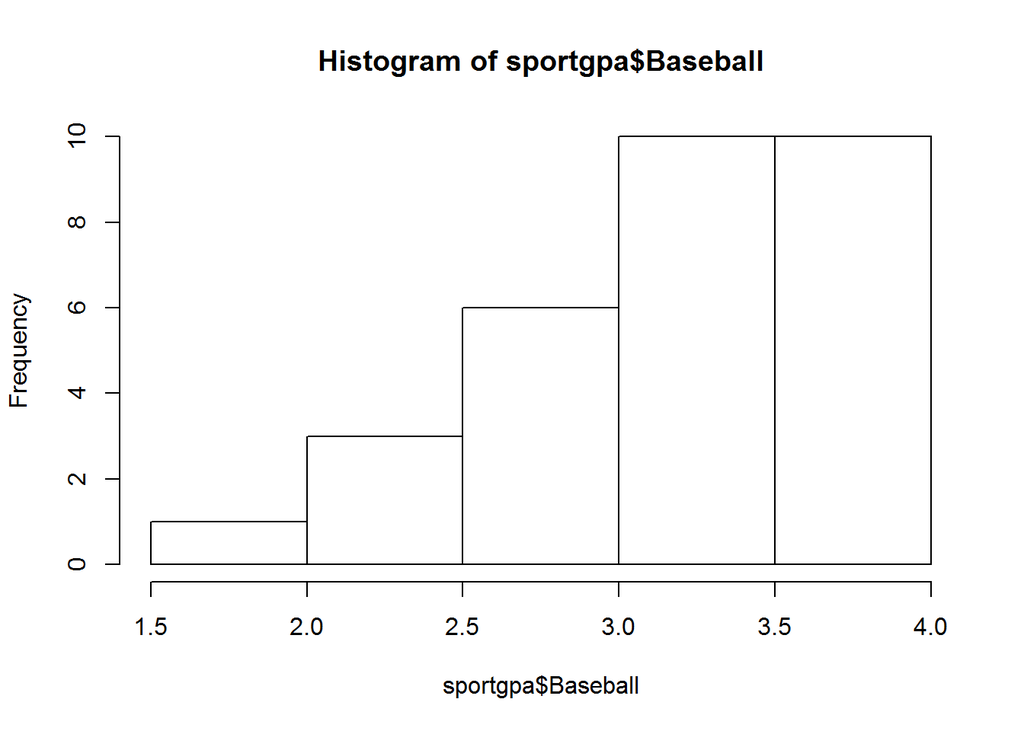

```r
hist(sportgpa$Baseball)
```

# football

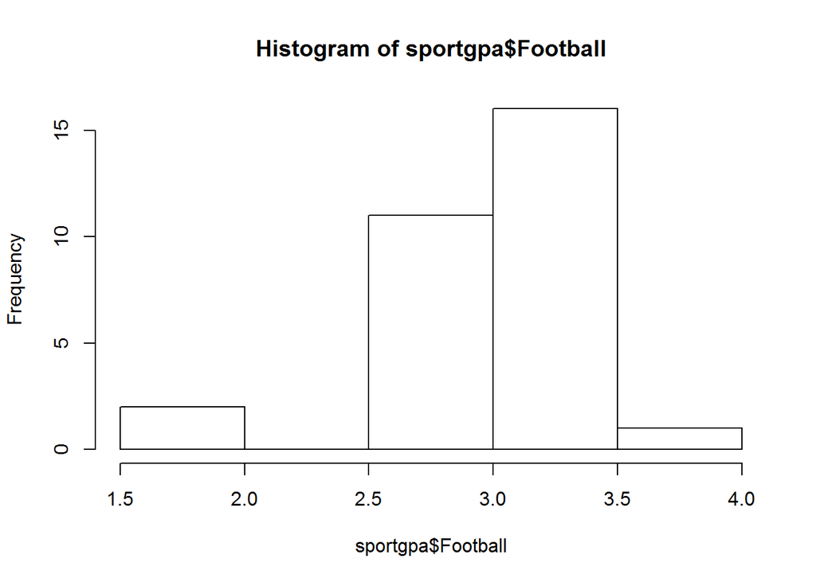

```r
hist(sportgpa$Football)
```

# soccer

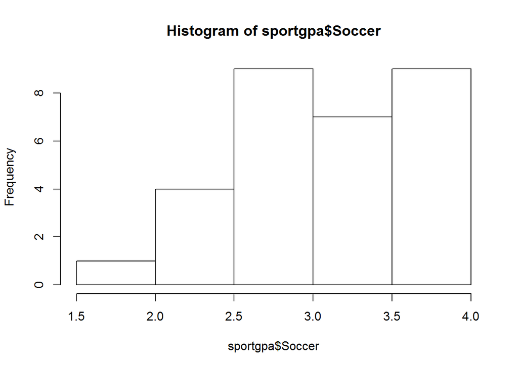

```r
hist(sportgpa$Soccer)
```

# softball

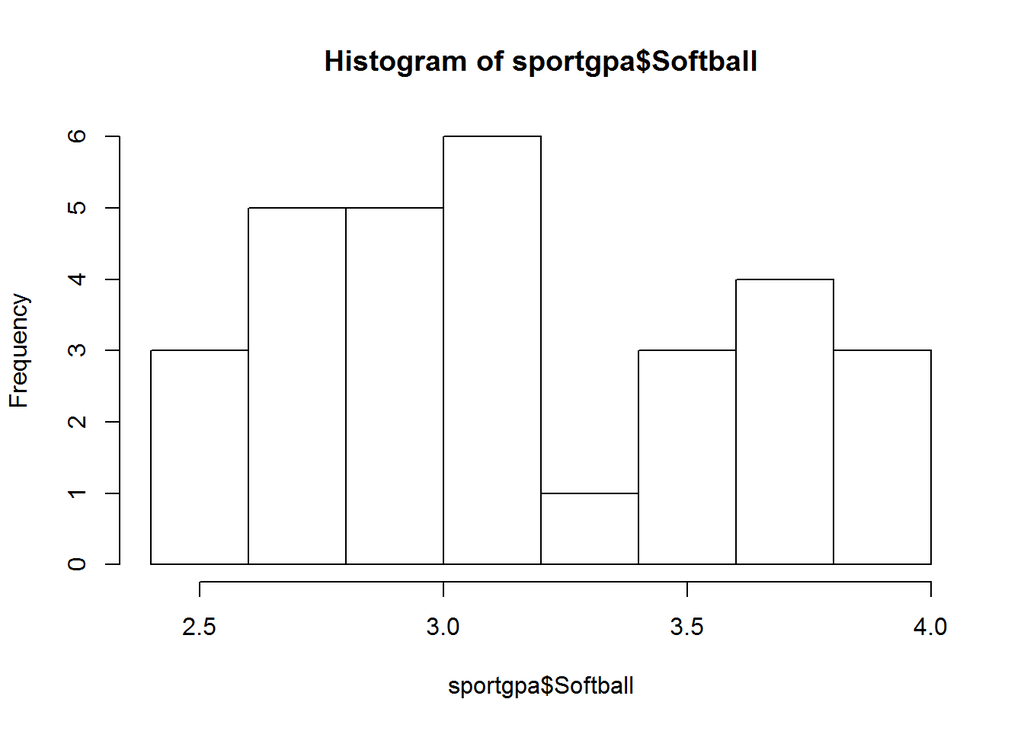

```r
hist(sportgpa$Softball)
```

# volleyball

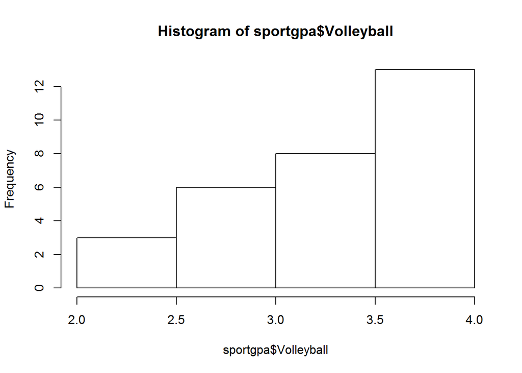

```r
hist(sportgpa$Volleyball)
```

```r
#Based on the historgrams, we do not see the histograms as normally distributed. Therefore, the assumption is not reasonably met.
```

**(d)** Unfortunately, this data is not configured in very efficient manner. Create a new `data.frame` object called `gpa_cleaned` that contains the same values but in the following configuration.

- `School` - Observation number representing the university
- `Sport` - Factor variable with levels of Baseball, Football, Soccer, Softball, Volleyball
- `GPA` - Average GPA of student-athletes

```r
Sport <-c(rep("Baseball",30),rep("Football",30),rep("Soccer",30),rep("Softball",30),rep("Volleyball",30))
GPA <-c(sportgpa$Baseball,sportgpa$Football,sportgpa$Soccer,sportgpa$Softball,sportgpa$Volleyball)
gpa_cleaned = data.frame(sportgpa$School,Sport,GPA)
```

**(e)** Perform the analysis of variance for the mean GPA of students in the five sports.

Report the following:

- The null and alternative hypotheses.
- The ANOVA table. (You may use `anova()` and omit the row for Total.)
- The value of the test statistic.
- The p-value of the test.
- A statistical decision at $\alpha = 0.05$.
- A conclusion in the context of the problem.

When reporting these, you should explicitly state them in your document, not assume that a reader will find and interpret them from a large block of `R` output.

```r
#Null: There is no significant linear relationship betwen gpa and sports. beta_1 = 0
#Alternative: There is a significant linear relationship between gpa and sports. beta_1 != 0

gpa_cleaned = data.frame(sportgpa$School,Sport,GPA)
summary(gpa_cleaned)
```

```
##  sportgpa.School        Sport         GPA
##  Min.   : 1.0    Baseball  :30   Min.   :1.780
##  1st Qu.: 8.0    Football  :30   1st Qu.:2.743
##  Median :15.5    Soccer    :30   Median :3.160
##  Mean   :15.5    Softball  :30   Mean   :3.143
##  3rd Qu.:23.0    Volleyball:30   3rd Qu.:3.580
##  Max.   :30.0                    Max.   :4.000
```

```r
gpa_full = lm(gpa_cleaned$GPA ~ gpa_cleaned$Sport)
gpa_null = lm(gpa_cleaned$GPA ~ 1)
anova(gpa_null,gpa_full)
```

```
## Analysis of Variance Table
##
## Model 1: gpa_cleaned$GPA ~ 1
## Model 2: gpa_cleaned$GPA ~ gpa_cleaned$Sport
##   Res.Df    RSS Df Sum of Sq      F Pr(>F)
## 1    149 39.019
## 2    145 37.040  4    1.9793 1.9371 0.1074
```

```r
#Test statistic value is 1.9371
#P value of test is 0.1074
#The p-value is greater than alpha, so we fail to reject the null hypothesis at alpha 0.05
#We do not have a significant regression, there is no significant linear relationship between GPA and sports.
```